# Red Wine Exploration

### Sulphur Dioxide, Alcohol and Quality

Our bivariate exploration of total sulfur dioxide versus quality indicated that these two data elements are not strongly correlated. We also found that alcohol was moderately positively correlated to quality. We now want to see a scatter plot that allows us compare all three variables: slcohol, sulfur dioxide and quality.

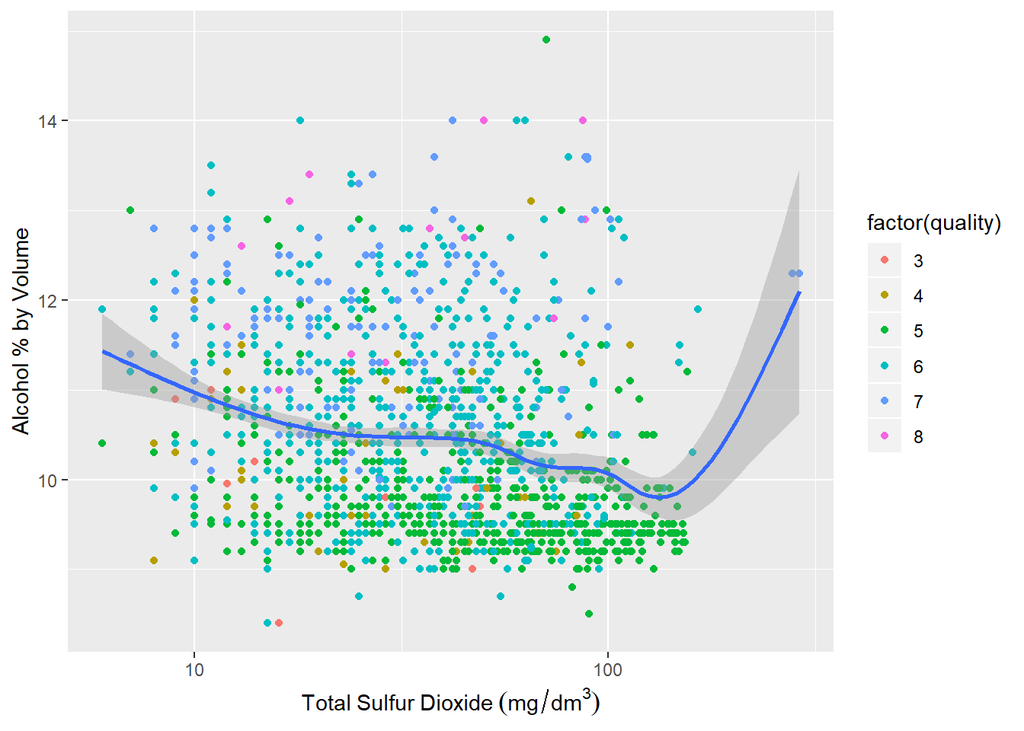

Scatter plot allows us spot the trend of higher quality wines tending to have higher levels of alcohol. We also observe wines with quality rating of 5 clustering at lower levels of alcohol content.

### Sulphates, Alcohol and Quality

In the earlier section we tried to establish a link between total sulfur dioxide, alcohol content and quality rating. Sulfur dioxide as we’ve previously seen is closely related to sulphates. So we should also perform a similar test as above, but using sulphates.

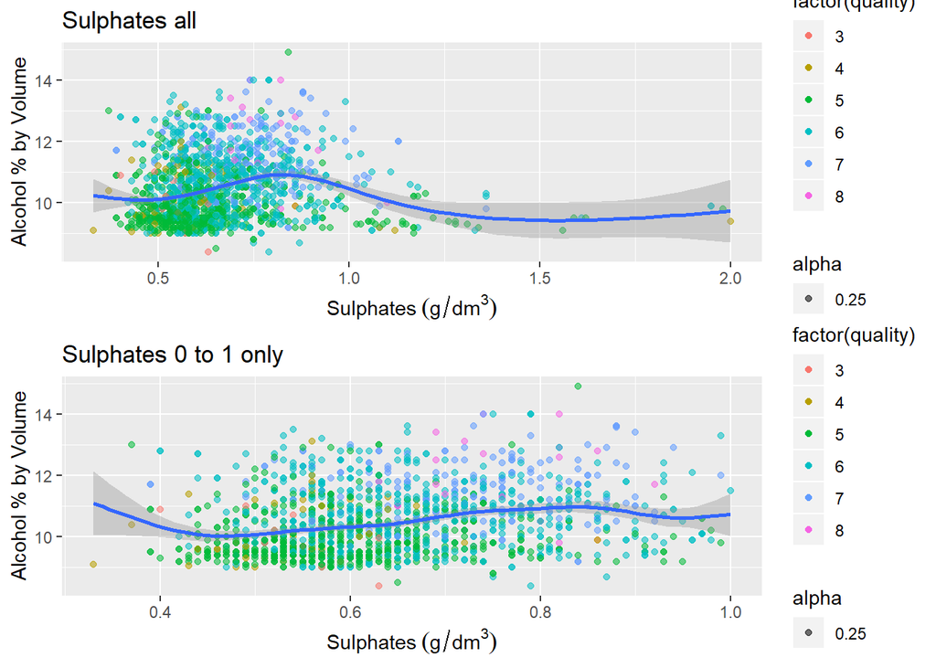

First, from the above scatter plot2, we can dismiss entirely the notion that alcohol content is inversely or otherwise related to sulphates, as we’ve seen earlier with sulfur dioxide versus alcohol. Further, we plotted the second graph using sulphates values of 1 and below, to better view the clustering within that range. We can see the trend line does not change in this narrower range. There is little correlation between sulphates and alcohol level, and higher quality wines are more likely to have higher alcohol content.

### Density, Alcohol and Quality

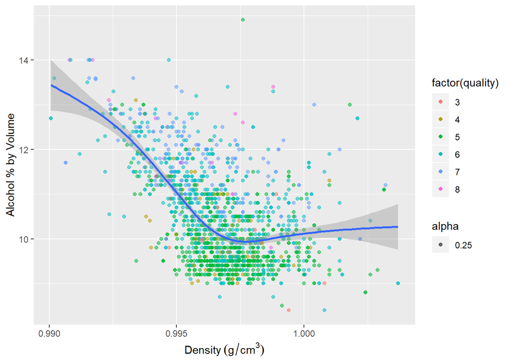

Here we compare alcohol content to density, and overlay with quality (which we have already seen correlates with alcohol).

So higher quality wines tend to be of lower density, and higher quality wines tend to have more alcohol. But both these relationships, while significant, are not overwhelmingly strong or evident from the plot.

# Final Plots and Summary

Below are some key plots (or plot sets) within this exploration that I found quite interesting and enlightening.

## Wine Composition

This chart below helped me understand wine composition. Fixed acids are clearly the dominant component, giving red wine its characteristic sour taste. Residual sugar is next largest component. Wine makers balance acids with sugars, adding sugars as necessary. Seeing this plotted in a pie chart was quite exciting.

This of course assumes the compounds listed in our dataset are complete and correct.

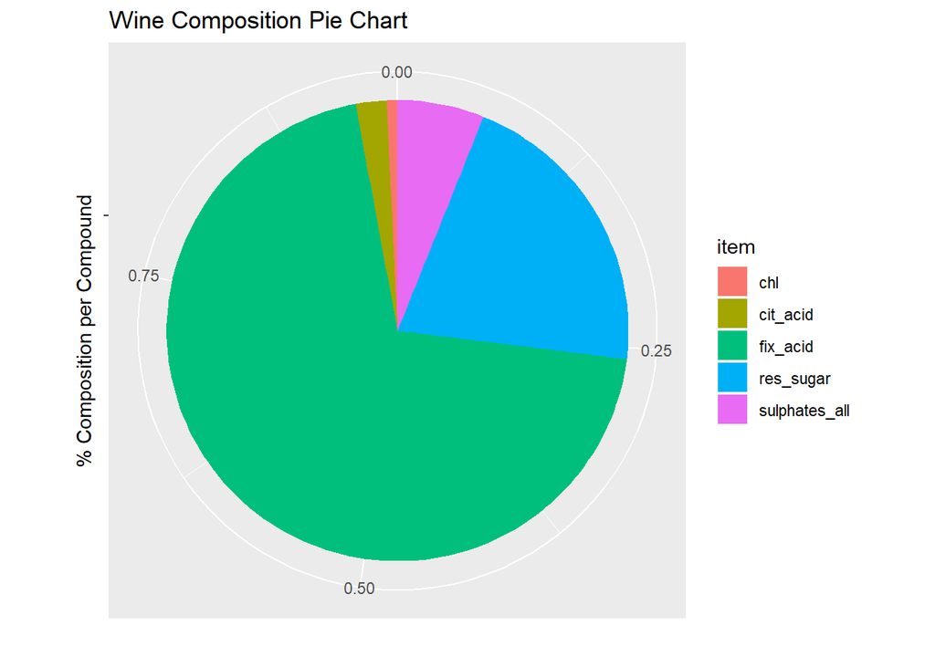

## Attributes That Most Affect Quality

My analysis did show that while most of the compounds in wine do not by themselves correlate to quality, a few do stand out as having a moderate correlation. Here I show which of these compounds and attributes have the most significant correlations to quality.

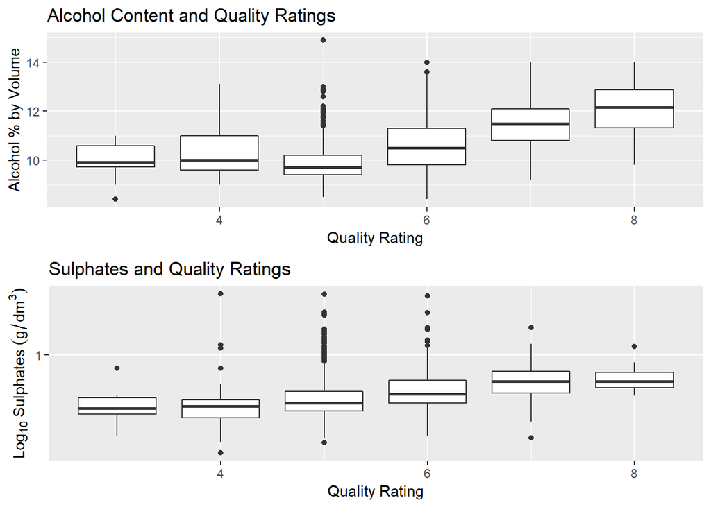

## Multivariate plot of alcohol, density and quality

Another thing I found interesting in this exploration was the non-intuitive negative (albeit, weak) correlation between density and quality, and the moderate negative correlation between density and alcohol. So essentially, denser wines are likely to be lower in alcohol content.

I’ve replicated the plot here.

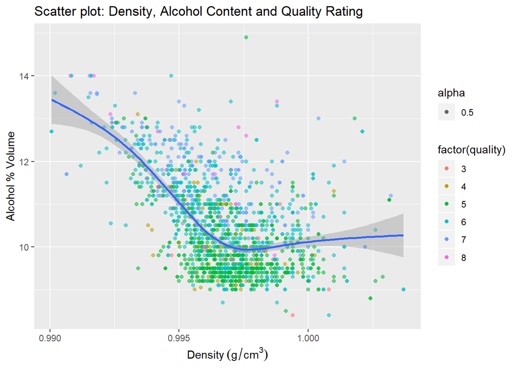

## Summary

It has been an exciting and enlightening journey through this dataset. Being a wine drinker, it has been educational to learn of the components of wine and investigate how each of these components and properties contribute to the final product, and gain remarkable insight into wine making.

I have learned that acids, which give wine its sour taste, and sugars, which counteract the effect of acids account for the bulk of disolved compounds in wine. Other compounds are sulphates which act as preservative, and citric acid which give wine its tangy taste.

I have learned that while alcohol and sulphates can moderately predict wine quality, many of the other major components of wine are poor predictors by themselves: acidity and residual sugar for example do not predict wine quality.

It will be a delight at some point to come back to this dataset to continue the exploration.

# Reflections

I have advanced my knowledge of R programming, particularly data visualization, and that I count as a major win from this mini-project. By investigating and exploring this dataset, I am in a position, to create deeper predictive models.

Besides the time constraint, there were not many difficulties with this project. R is obviously a deep and rich language, and I look forward to my continuing data analysis journey in R.

### Future Exploration

To what degree does each component or attribute of wine contribute to its quality rating? I will answer this question using lm() function. Variables I will include are acidity, residual sugar, citric acid, sulphates and sulfur dioxide, density, alcohol and pH.

Another question for future exploration: what can I learn about wines generally by employing summary functions (mean, median, mode, etc) on each of the principal attributes of wine. This will help me better understand the disposition and ranges of each attribute and compositional component of wine. I already prepared the dataframe for this, so will be interesting to take the analysis further.

# References

Dataset: https://www.google.com/url?q=https://s3.amazonaws.com/udacity-hosted-downloads/ud651/wineQualityReds.csv&sa=D&ust=1532329009931000 https://s3.amazonaws.com/udacity-hosted-downloads/ud651/wineQualityInfo.txt

Web resources: https://stackoverflow.com/ http://www.sthda.com/english/wiki/ggplot2-pie-chart-quick-start-guide-r-software-and-data-visualization http://www.sthda.com/english/wiki/be-awesome-in-ggplot2-a-practical-guide-to-be-highly-effective-r-software-and-data-visualization#geom_freqpoly-frequency-polygon https://www.statmethods.net/advgraphs/parameters.html http://www.morethanorganic.com/sulphur-in-wine https://en.wikipedia.org/wiki/Acids_in_wine https://stats.stackexchange.com/questions/101274/how-to-interpret-a-qq-plot